# employee.csv

2024-04-19

## R Markdown

Nos conectamos al dataset:

**Diccionario de Datos**

Education: The educational qualifications of employees, including degree, institution, and field of study.

Joining Year: The year each employee joined the company, indicating their length of service.

City: The location or city where each employee is based or works.

Payment Tier: Categorization of employees into different salary tiers.

Age: The age of each employee, providing demographic insights.

Gender: Gender identity of employees, promoting diversity analysis.

Ever Benched: Indicates if an employee has ever been temporarily without assigned work.

Experience in Current Domain: The number of years of experience employees have in their current field.

Leave or Not: a target column

**Conexión al dataset Employee.csv**

El dataset “Employee.csv” se encuentra en nuestro repositorio de Github al cual nos conectamos utiliando el método read.csv.

```r
url <- "https://raw.githubusercontent.com/chelocoder/ProyectoR/main/Employee.csv"
datos <- read.csv(url)
head(datos)
```

```
##   Education JoiningYear      City PaymentTier Age Gender EverBenched
## 1 Bachelors        2017 Bangalore           3  34   Male          No
## 2 Bachelors        2013      Pune           1  28 Female          No
## 3 Bachelors        2014 New Delhi           3  38 Female          No
## 4   Masters        2016 Bangalore           3  27   Male          No
## 5   Masters        2017      Pune           3  24   Male         Yes
## 6 Bachelors        2016 Bangalore           3  22   Male          No
##   ExperienceInCurrentDomain LeaveOrNot
## 1                         0          0
## 2                         3          1
## 3                         2          0
## 4                         5          1
## 5                         2          1
## 6                         0          0
```

El comando head nos permite visualizar los primeros seis registros como una vista previa que confirma la conexión y nos permite una primera vista preliminar de los datos.

Empezamos con la estadística descriptiva, esta es una rama importante de la estadística que nos permite describir las características de los datos, de ahí su nombre, pertenece a la etapa del análisis descriptivo donde empezamos a conocer los datos.

Sus partes más importantes son:

1. Estadísticos de tendencia central.
2. Estadísticos de dispersión.

## 1. Estadísticos Descriptivos

Obtenemos los estadísticos descriptivos de todas las variables del dataset de forma resumida:

```r
# Obtener estadísticos descriptivos
summary_stats <- summary(datos)

# Mostrar estadísticos descriptivos
print(summary_stats)
```

```
##   Education          JoiningYear       City            PaymentTier
##  Length:4653        Min.   :2012   Length:4653        Min.   :1.000
##  Class :character   1st Qu.:2013   Class :character   1st Qu.:3.000
##  Mode  :character   Median :2015   Mode  :character   Median :3.000
##                     Mean   :2015                      Mean   :2.698
##                     3rd Qu.:2017                      3rd Qu.:3.000
##                     Max.   :2018                      Max.   :3.000
##       Age           Gender          EverBenched
##  Min.   :22.00   Length:4653        Length:4653
##  1st Qu.:26.00   Class :character   Class :character
##  Median :28.00   Mode  :character   Mode  :character
##  Mean   :29.39
##  3rd Qu.:32.00
##  Max.   :41.00
##  ExperienceInCurrentDomain   LeaveOrNot
##  Min.   :0.000             Min.   :0.0000
##  1st Qu.:2.000             1st Qu.:0.0000
##  Median :3.000             Median :0.0000
##  Mean   :2.906             Mean   :0.3439
##  3rd Qu.:4.000             3rd Qu.:1.0000
##  Max.   :7.000             Max.   :1.0000
```

Ahora vamos a describir cada una de las características:

## 1.1. Tendecia Central

Para un mejor análisis dividimos a las variables del dataset en: Variables numéricas y categóricas.

**1.1.1 Variables Numéricas**

Obtenemos los Estadísticos descriptivos de solamente las variables numéricas

```
##   JoiningYear    PaymentTier         Age        ExperienceInCurrentDomain
##  Min.   :2012   Min.   :1.000   Min.   :22.00   Min.   :0.000
##  1st Qu.:2013   1st Qu.:3.000   1st Qu.:26.00   1st Qu.:2.000
##  Median :2015   Median :3.000   Median :28.00   Median :3.000
##  Mean   :2015   Mean   :2.698   Mean   :29.39   Mean   :2.906
##  3rd Qu.:2017   3rd Qu.:3.000   3rd Qu.:32.00   3rd Qu.:4.000
##  Max.   :2018   Max.   :3.000   Max.   :41.00   Max.   :7.000
##    LeaveOrNot
##  Min.   :0.0000
##  1st Qu.:0.0000
##  Median :0.0000
##  Mean   :0.3439
##  3rd Qu.:1.0000
##  Max.   :1.0000
```

Obtenemos los estadísticos descriptivos de cada variable para describir mejor las características de las variables numéricas:

**a.Variable JoiningYear**

**a.1.Valor Mínimo:**

```r
# Obtener el valor mínimo
min <- min(datos$JoiningYear)

# Imprimir el valor mínimo de la columna
print(min)
```

```
## [1] 2012
```

El menor año en que se contrató a un empleado fue el año 2012.

**a.2.Primer Cuartil:**

```r
# Obtener el primer cuartil
q1 <- quantile(datos$JoiningYear, 0.25)

# Imprimir el primer cuartil
print(q1)
```

```
##  25%
## 2013
```

El año 2013 es igual o mayor al 25% de los años e igual o menor al 75% de los años de contratación.

**a.3. Mediana:**

```r
# Calcular la mediana de la variable
mediana_joining_year <- median(datos$JoiningYear)

# Imprimir la mediana de la variable
print(mediana_joining_year)
```

```
## [1] 2015
```

El año 2015 es igual o mayor al 50% de los años e igual o menor al 50% de los años de contratación.

**a.4.Tercer Cuartil:**

```r
# Obtener el tercer cuartil
q3 <- quantile(datos$JoiningYear, 0.75)

# Imprimir el tercer cuartil
print(q3)
```

```
##  75%
## 2017
```

El año 2017 es igual o mayor al 75% de los años e igual o menor al 25% de los años de contratación.

**a.5.Valor Máximo:**

```r
# Calcular el valor máximo de la variable
max <- max(datos$JoiningYear)

# Imprimir el valor máximo de la variable
print(max)
```

```
## [1] 2018
```

El mayor año en que se contrató a un empleado fue el año 2018.

**a.6.Recorrido (Rango):**

```r
# Calcular el rango de la variable
rango <- max(datos$JoiningYear) - min(datos$JoiningYear)

# Imprimir el rango de la variable "JoiningYear"
print(rango)
```

```
## [1] 6
```

La diferencia entre el valor mayor y el valor menor es 6 (rango o recorrido).

**a.7.Moda:**

```r
# Calcular la moda de la variable
moda <- as.numeric(names(sort(-table(datos$JoiningYear))[1]))

# Imprimir la moda de la variable
print(moda)
```

```
## [1] 2017
```

La moda es 2017 que es el valor que más se repite, es decir el que presenta la frecuencia más alta.

**a.8.Frecuencia Mayor:**

```r
# Calcular la frecuencia de la variable
frecuencia <- table(datos$JoiningYear)

# Imprimir la frecuencia de la variable
print(frecuencia)
```

```
##
## 2012 2013 2014 2015 2016 2017 2018
##  504  669  699  781  525 1108  367
```

```r
#Imprimir la frecuencia máxima
frecuencia_maxima <- max(frecuencia)
print(frecuencia_maxima)
```

```
## [1] 1108
```

La frecuencia mayor es 1108 que determina la moda, es decir el valor que más se repite.

**a.9.Media:**

```r
media <- mean(datos$JoiningYear)
print(media)
```

```
## [1] 2015.063
```

La media es 2015.063, es decir si la distirbución es simétrica y no hay valores atípicos, en promedio, los empleados de la empresa son contratados el año 2015, sin embargo, si la distirbución es asimétrica o hay valores atípicos una medida más representativa sería la mediana.

**b.Variable PaymentTier**

**b.1.Valor Mínimo:**

```r
# Obtener el valor mínimo
min <- min(datos$PaymentTier)

# Imprimir el valor mínimo de la columna
print(min)
```

```
## [1] 1
```

El menor código de categoría de pagos es 1.

**b.2.Primer Cuartil:**

```r
# Obtener el primer cuartil
q1 <- quantile(datos$PaymentTier, 0.25)

# Imprimir el primer cuartil
print(q1)
```

```
## 25%
##   3
```

El valor 3 es igual o mayor al 25% de las categorías de pago e igual o menor al 75% de las categorías de pago.

**b.3. Mediana:**

```r
# Calcular la mediana de la variable
mediana <- median(datos$PaymentTier)

# Imprimir la mediana de la variable
print(mediana)
```

```
## [1] 3
```

El valor 3 es igual o mayor al 50% de las categorías de pago e igual o menor al 50% de las categorías de pago.

**b.4.Tercer Cuartil:**

```r
# Obtener el tercer cuartil
q3 <- quantile(datos$PaymentTier, 0.75)

# Imprimir el tercer cuartil
print(q3)
```

```
## 75%
##   3
```

El valor 3 es igual o mayor al 75% de las categorías de pago e igual o menor al 25% de las categorías de pago.

**b.5.Valor Máximo:**

```r
# Calcular el valor máximo de la variable
max <- max(datos$PaymentTier)

# Imprimir el valor máximo de la variable
print(max)
```

```
## [1] 3
```

El mayor código de categoría de pagos es 3.

**b.6.Recorrido (Rango):**

```r
# Calcular el rango de la variable
rango <- max(datos$PaymentTier) - min(datos$PaymentTier)

# Imprimir el rango de la variable
print(rango)
```

```
## [1] 2
```

La diferencia entre el valor mayor y el valor menor es 2 (rango o recorrido).

**b.7.Moda:**

```r
# Calcular la moda de la variable
moda <- as.numeric(names(sort(-table(datos$PaymentTier))[1]))

# Imprimir la moda de la variable
print(moda)
```

```
## [1] 3
```

La moda es 3 que es el valor que más se repite, es decir el que presenta la frecuencia más alta.

**b.8.Frecuencia:**

```r
# Calcular la frecuencia de la variable
frecuencia <- table(datos$PaymentTier)

# Imprimir la frecuencia de la variable
print(frecuencia)
```

```
##
##    1    2    3
##  243  918 3492
```

```r
#Imprimir la frecuencia máxima
frecuencia_maxima <- max(frecuencia)
print(frecuencia_maxima)
```

```
## [1] 3492
```

La frecuencia mayor es 3492 que determina la moda, es decir el valor que más se repite.

```r
media <- mean(datos$PaymentTier)
print(media)
```

```
## [1] 2.698259
```

**c.Variable Age**

**c.1.Valor Mínimo:**

```r
# Obtener el valor mínimo
min <- min(datos$Age        )

# Imprimir el valor mínimo de la columna
print(min)
```

```
## [1] 22
```

**c.2.Primer Cuartil:**

```r
# Obtener el primer cuartil
q1 <- quantile(datos$Age        , 0.25)

# Imprimir el primer cuartil
print(q1)
```

```
## 25%
##  26
```

**c.3. Mediana:**

```r
# Calcular la mediana de la variable
mediana <- median(datos$Age)

# Imprimir la mediana de la variable
print(mediana)
```

```
## [1] 28
```

**c.4.Tercer Cuartil:**

```r
# Obtener el tercer cuartil
q3 <- quantile(datos$PaymentTier, 0.75)

# Imprimir el tercer cuartil
print(q3)
```

[output not shown]

**c.5.Valor Máximo:**

```r
# Calcular el valor máximo de la variable
max <- max(datos$Age        )

# Imprimir el valor máximo de la variable
print(max)
```

```
## [1] 41
```

**c.6.Recorrido (Rango):**

```r
# Calcular el rango de la variable
rango <- max(datos$Age) - min(datos$Age)

# Imprimir el rango de la variable
print(rango)
```

```
## [1] 19
```

**c.7.Moda:**

```r
# Calcular la moda de la variable
moda <- as.numeric(names(sort(-table(datos$Age))[1]))

# Imprimir la moda de la variable
print(moda)
```

```
## [1] 26
```

**c.8.Frecuencia:**

```r
# Calcular la frecuencia de la variable
frecuencia <- table(datos$Age)

# Imprimir la frecuencia de la variable
print(frecuencia)
```

```
##
##  22  23  24  25  26  27  28  29  30  31  32  33  34  35  36  37  38  39  40  41
##  49  48 385 418 645 625 630 230 220 125 132 124 136 123 139 141 136 131 134  82
```

```r
#Imprimir la frecuencia máxima
frecuencia_maxima <- max(frecuencia)
print(frecuencia_maxima)
```

```
## [1] 645
```

**d.Variable ExperienceInCurrentDomain**

**d.1.Valor Mínimo:**

```r
# Obtener el valor mínimo
min <- min(datos$ExperienceInCurrentDomain)

# Imprimir el valor mínimo de la columna
print(min)
```

```
## [1] 0
```

**d.2.Primer Cuartil:**

```r
# Obtener el primer cuartil
q1 <- quantile(datos$ExperienceInCurrentDomain, 0.25)

# Imprimir el primer cuartil
print(q1)
```

```
## 25%
##   2
```

**d.3. Mediana:**

```r
# Calcular la mediana de la variable
mediana <- median(datos$ExperienceInCurrentDomain)

# Imprimir la mediana de la variable
print(mediana)
```

```
## [1] 3
```

**d.4.Tercer Cuartil:**

```r
# Obtener el tercer cuartil
q3 <- quantile(datos$ExperienceInCurrentDomain, 0.75)

# Imprimir el tercer cuartil
print(q3)
```

```
## 75%
##   4
```

**d.5.Valor Máximo:**

```r
# Calcular el valor máximo de la variable
max <- max(datos$ExperienceInCurrentDomain)

# Imprimir el valor máximo de la variable
print(max)
```

```
## [1] 7
```

**d.6.Recorrido (Rango):**

```r
# Calcular el rango de la variable
rango <- max(datos$ExperienceInCurrentDomain) - min(datos$ExperienceInCurrentDomain)

# Imprimir el rango de la variable
print(rango)
```

```
## [1] 7
```

**d.7.Moda:**

```r
# Calcular la moda de la variable
moda <- as.numeric(names(sort(-table(datos$ExperienceInCurrentDomain))[1]))

# Imprimir la moda de la variable
print(moda)
```

```
## [1] 2
```

**d.8.Frecuencia:**

```r
# Calcular la frecuencia de la variable
frecuencia <- table(datos$ExperienceInCurrentDomain)

# Imprimir la frecuencia de la variable
print(frecuencia)
```

```
##
##    0    1    2    3    4    5    6    7
##  355  558 1087  786  931  919    8    9
```

```r
#Imprimir la frecuencia máxima
frecuencia_maxima <- max(frecuencia)
print(frecuencia_maxima)
```

```
## [1] 1087
```

**e.Variable LeaveOrNot**

**e.1.Valor Mínimo:**

```r
# Obtener el valor mínimo
min <- min(datos$LeaveOrNot)

# Imprimir el valor mínimo de la columna
print(min)
```

```
## [1] 0
```

**e.2.Primer Cuartil:**

```r
# Obtener el primer cuartil
q1 <- quantile(datos$LeaveOrNot, 0.25)

# Imprimir el primer cuartil
print(q1)
```

```
## 25%
##   0
```

**e.3. Mediana:**

```r
# Calcular la mediana de la variable
mediana <- median(datos$LeaveOrNot)

# Imprimir la mediana de la variable
print(mediana)
```

```
## [1] 0
```

**e.4.Tercer Cuartil:**

```r
# Obtener el tercer cuartil
q3 <- quantile(datos$LeaveOrNot, 0.75)

# Imprimir el tercer cuartil
print(q3)
```

```
## 75%
##   1
```

**e.5.Valor Máximo:**

```r
# Calcular el valor máximo de la variable
max <- max(datos$LeaveOrNot)

# Imprimir el valor máximo de la variable
print(max)
```

```
## [1] 1
```

**e.6.Recorrido (Rango):**

```r
# Calcular el rango de la variable
rango <- max(datos$LeaveOrNot) - min(datos$LeaveOrNot)

# Imprimir el rango de la variable
print(rango)
```

```
## [1] 1
```

**e.7.Moda:**

```r
# Calcular la moda de la variable
moda <- as.numeric(names(sort(-table(datos$LeaveOrNot))[1]))

# Imprimir la moda de la variable
print(moda)
```

```
## [1] 0
```

**e.8.Frecuencia:**

```r
# Calcular la frecuencia de la variable
frecuencia <- table(datos$LeaveOrNot)

# Imprimir la frecuencia de la variable
print(frecuencia)
```

```
##
##    0    1
## 3053 1600
```

```r
#Imprimir la frecuencia máxima
frecuencia_maxima <- max(frecuencia)
print(frecuencia_maxima)
```

```
## [1] 3053
```

**1.1.2 Variables Categóricas**

Obtenemos los estadísticos descriptivos de las variables categóricas

```r
# Seleccionar solo las columnas categóricas
categorical_data <- datos %>%
  select_if(is.character)

# Obtener estadísticos descriptivos para las variables categóricas
summary_stats_categorical <- summary(categorical_data)

# Imprimir los estadísticos descriptivos
print(summary_stats_categorical)
```

```
##   Education             City              Gender          EverBenched
##  Length:4653        Length:4653        Length:4653        Length:4653
##  Class :character   Class :character   Class :character   Class :character
##  Mode  :character   Mode  :character   Mode  :character   Mode  :character
```

Obtenemos los estadísticos descriptivos de cada variable:

**a.Variable Education**

**a.1.Frecuencia:**

```r
# Calcular la frecuencia de cada valor en la variable categórica
frecuencia <- table(datos$Education)

# Imprimir los valores y sus frecuencias
print(frecuencia)
```

```
##
## Bachelors   Masters       PHD
##      3601       873       179
```

**a.2.Moda:**

```r
# Calcular la frecuencia de cada valor en la variable categórica
frecuencia <- table(datos$Education)

# Encontrar el valor que más se repite
valor_mas_repetido <- names(frecuencia)[which.max(frecuencia)]

# Imprimir el valor que más se repite
print(valor_mas_repetido)
```

```
## [1] "Bachelors"
```

**b.Variable City**

**b.1.Frecuencia:**

```r
# Calcular la frecuencia de cada valor en la variable categórica
frecuencia <- table(datos$City)

# Imprimir los valores y sus frecuencias
print(frecuencia)
```

```
##
## Bangalore New Delhi      Pune
##      2228      1157      1268
```

**b.2.Moda:**

```r
# Calcular la frecuencia de cada valor en la variable categórica
frecuencia <- table(datos$City)

# Encontrar el valor que más se repite
valor_mas_repetido <- names(frecuencia)[which.max(frecuencia)]

# Imprimir el valor que más se repite
print(valor_mas_repetido)
```

```
## [1] "Bangalore"
```

**c.Variable Gender**

**c.1.Frecuencia:**

```r
# Calcular la frecuencia de cada valor en la variable categórica
frecuencia <- table(datos$Gender)

# Imprimir los valores y sus frecuencias
print(frecuencia)
```

```
##
## Female   Male
##   1875   2778
```

**c.2.Moda:**

```r
# Calcular la frecuencia de cada valor en la variable categórica
frecuencia <- table(datos$Gender)

# Encontrar el valor que más se repite
valor_mas_repetido <- names(frecuencia)[which.max(frecuencia)]

# Imprimir el valor que más se repite
print(valor_mas_repetido)
```

```
## [1] "Male"
```

**d.Variable EverBenched**

**d.1.Frecuencia:**

```r
# Calcular la frecuencia de cada valor en la variable categórica
frecuencia <- table(datos$EverBenched)

# Imprimir los valores y sus frecuencias
print(frecuencia)
```

```
##
##   No  Yes
## 4175  478
```

**d.2.Moda:**

```r
# Calcular la frecuencia de cada valor en la variable categórica
frecuencia <- table(datos$EverBenched)

# Encontrar el valor que más se repite
valor_mas_repetido <- names(frecuencia)[which.max(frecuencia)]

# Imprimir el valor que más se repite
print(valor_mas_repetido)
```

```
## [1] "No"
```

## 1.2. Dispersión

**1.1.1 Variables Numéricas**

```r
# Seleccionar solo las columnas numéricas
numeric_data <- datos %>%
  select_if(is.numeric)

# Calcular el rango
rango <- apply(numeric_data, 2, function(x) max(x) - min(x))

# Calcular la varianza
varianza <- apply(numeric_data, 2, var)

# Calcular la desviación estándar
desviacion_estandar <- apply(numeric_data, 2, sd)

# Crear un dataframe con los resultados
estadisticos_dispersion <- data.frame(
  Variable = names(numeric_data),
  Rango = rango,
  Varianza = varianza,
  Desviacion_Estandar = desviacion_estandar
)

# Imprimir los estadísticos de dispersión
print(estadisticos_dispersion)
```

```
##                                            Variable Rango   Varianza
## JoiningYear                             JoiningYear     6  3.4721732
## PaymentTier                             PaymentTier     2  0.3152098
## Age                                             Age    19 23.2911158
## ExperienceInCurrentDomain ExperienceInCurrentDomain     7  2.4281129
## LeaveOrNot                               LeaveOrNot     1  0.2256701
##                           Desviacion_Estandar
## JoiningYear                         1.8633768
## PaymentTier                         0.5614355
## Age                                 4.8260870
## ExperienceInCurrentDomain           1.5582403
## LeaveOrNot                          0.4750475
```

## 2. Análisis Exploratorio de Datos (EDA)

```r
# Conteo de datos faltantes en cada columna
missing_data_counts <- sapply(datos, function(x) sum(is.na(x)))

# Mostrando el conteo de datos faltantes
missing_data_counts
```

```
##                 Education               JoiningYear                      City
##                         0                         0                         0
##               PaymentTier                       Age                    Gender
##                         0                         0                         0
##               EverBenched ExperienceInCurrentDomain                LeaveOrNot
##                         0                         0                         0
```

Como contamos con pocas variables, se puede destacar a primera vista que tenemos 8 variables independientes y 1 dependiente. De las variables independientes, 4 son categóricas y 4 son numéricas. La variable dependiente es numérica.

```r
# Identificando variables numéricas
numeric_vars <- sapply(datos, function(x) is.numeric(x) || is.integer(x))
numeric_variables <- names(datos)[numeric_vars]

# Identificando variables categóricas
categorical_vars <- sapply(datos, function(x) is.factor(x) || is.character(x) || is.logical(x))
categorical_variables <- names(datos)[categorical_vars]

# Mostrando las variables numéricas y categóricas
list(numeric = numeric_variables, categorical = categorical_variables)
```

```
## $numeric
## [1] "JoiningYear"               "PaymentTier"
## [3] "Age"                       "ExperienceInCurrentDomain"
## [5] "LeaveOrNot"
##
## $categorical
## [1] "Education"   "City"        "Gender"      "EverBenched"
```

Decidimos realizar un gráfico de barras de JoiningYear, debido a que su rango de valores era corto. Podemos observar que el año que tuvo más personas ingresando a trabajar fue el 2017 (23.8%) y el año con menos ingresos fue el 2018 (7.9%).

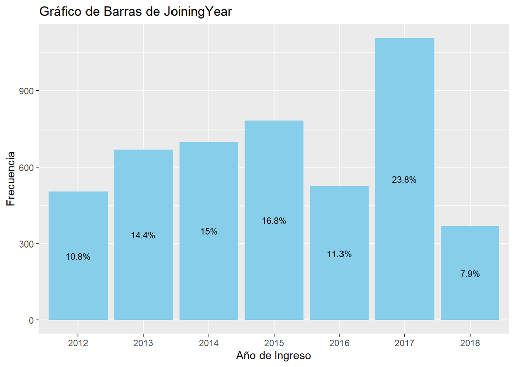

Gráfico de Barras de JoiningYear con ggplot2

```r
# Calcular los porcentajes de frecuencia de cada año
library(ggplot2)
joining_year_data <- as.data.frame(table(datos$JoiningYear))
joining_year_data$Percentage <- joining_year_data$Freq / sum(joining_year_data$Freq) * 100

# Crear el gráfico de barras con porcentajes usando ggplot2
ggplot(joining_year_data, aes(x = Var1, y = Freq, label = paste0(round(Percentage, 1), "%"))) +
  geom_bar(stat = "identity", fill = "skyblue") +
  geom_text(size = 3, position = position_stack(vjust = 0.5), color = "black") +
  ggtitle("Gráfico de Barras de JoiningYear") +
  xlab("Año de Ingreso") +
  ylab("Frecuencia")
```

Decidimos realizar un gráfico de barras de PaymentTier, debido a que su rango de valores era corto. Podemos observar que el Tier 3, que precisamente corresponde al salario más bajo, es el más frecuente (75%), mientras que el Tier 1, donde se gana más, es el menos frecuente (5.2%).

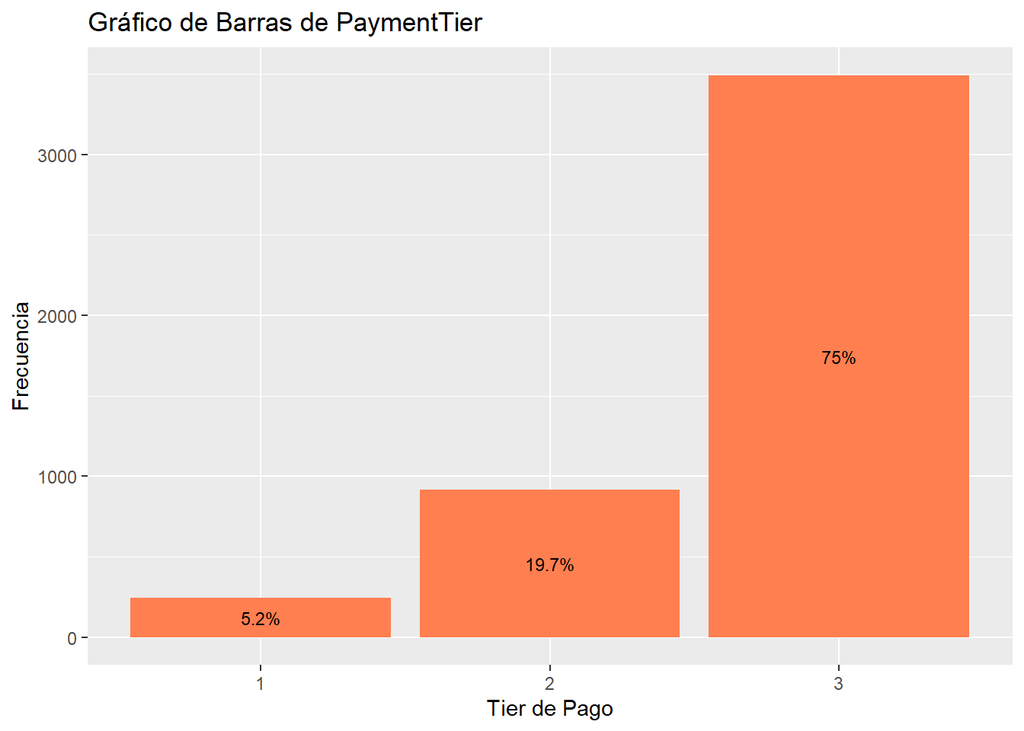

Gráfico de Barras de PaymentTier con ggplot2

```r
# Calcular los porcentajes de frecuencia de cada categoría de PaymentTier
library(ggplot2)
payment_tier_data <- as.data.frame(table(datos$PaymentTier))
payment_tier_data$Percentage <- payment_tier_data$Freq / sum(payment_tier_data$Freq) * 100

# Crear el gráfico de barras con porcentajes usando ggplot2
ggplot(payment_tier_data, aes(x = Var1, y = Freq, label = paste0(round(Percentage, 1), "%"))) +
  geom_bar(stat = "identity", fill = "coral") +
  geom_text(size = 3, position = position_stack(vjust = 0.5), color = "black") +
  ggtitle("Gráfico de Barras de PaymentTier") +
  xlab("Tier de Pago") +
  ylab("Frecuencia")
```

Decidimos realizar un histograma de Age, debido a que su rango de valores era más amplio. Podemos observar que hay mayor cantidad de personas que tienen entre 25 y 27 años, y la menor cantidad de personas son las que tienen entre 21 y 23 años. Ademas la data esta sesgada a la derecha.

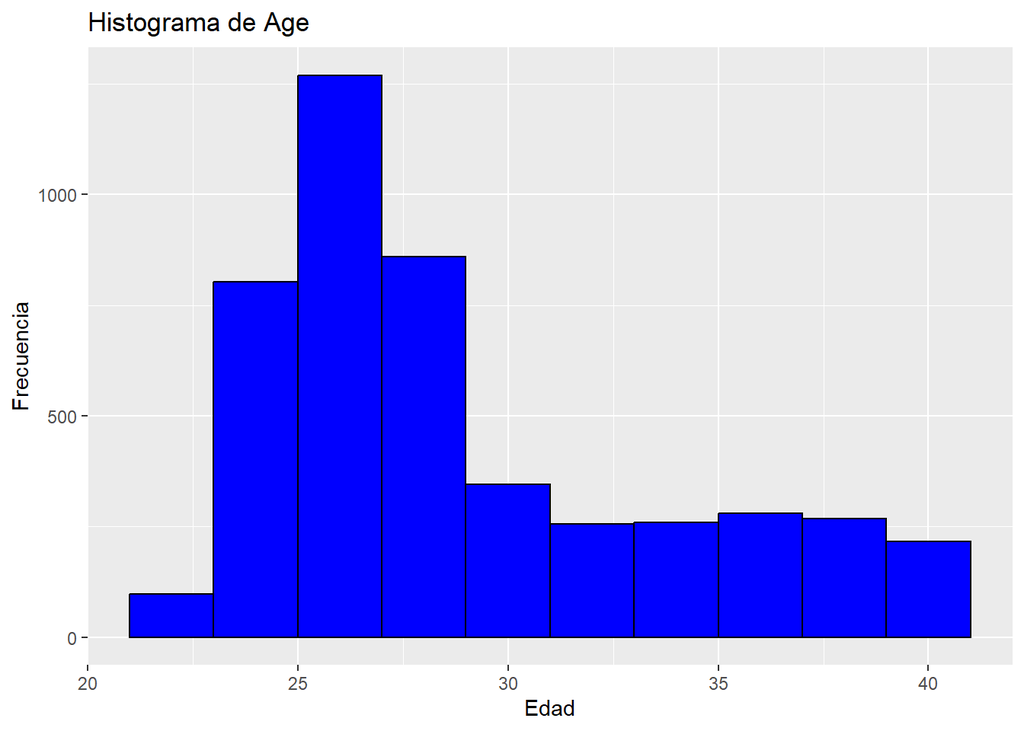

Histograma de Age con ggplot2

```r
# Cargar la librería ggplot2
library(ggplot2)

# Crear un histograma usando ggplot2
ggplot(datos, aes(x = Age)) +
  geom_histogram(binwidth = 2, fill="blue", color="black") +
  ggtitle("Histograma de Age") +
  xlab("Edad") +
  ylab("Frecuencia")
```

Adicionalmente, al analizar Age con un boxplot, podemos ver que no hay presencia de outliers.

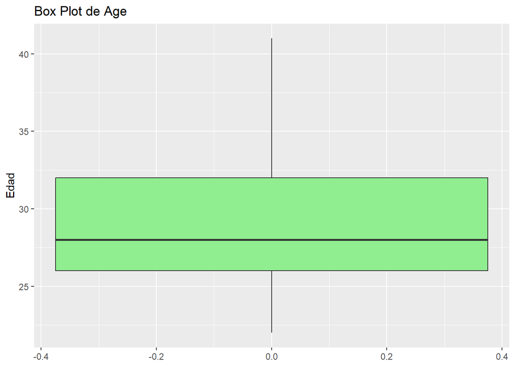

Box Plot de Age con ggplot2

```r
# Cargar la librería ggplot2
library(ggplot2)

# Creando un box plot usando ggplot2
ggplot(datos, aes(y = Age)) +
  geom_boxplot(fill = "lightgreen") +
  ggtitle("Box Plot de Age") +
  ylab("Edad")
```

Decidimos realizar un gráfico de barras de ExperienceInCurrentDomain, debido a que su rango de valores era corto. Podemos observar que la frecuencia más alta es cuando las personas tienen 2 años de experiencia (23.4%), mientras que la más baja es cuando tienen 6 o 7 años de experiencia (0.2% cada uno).

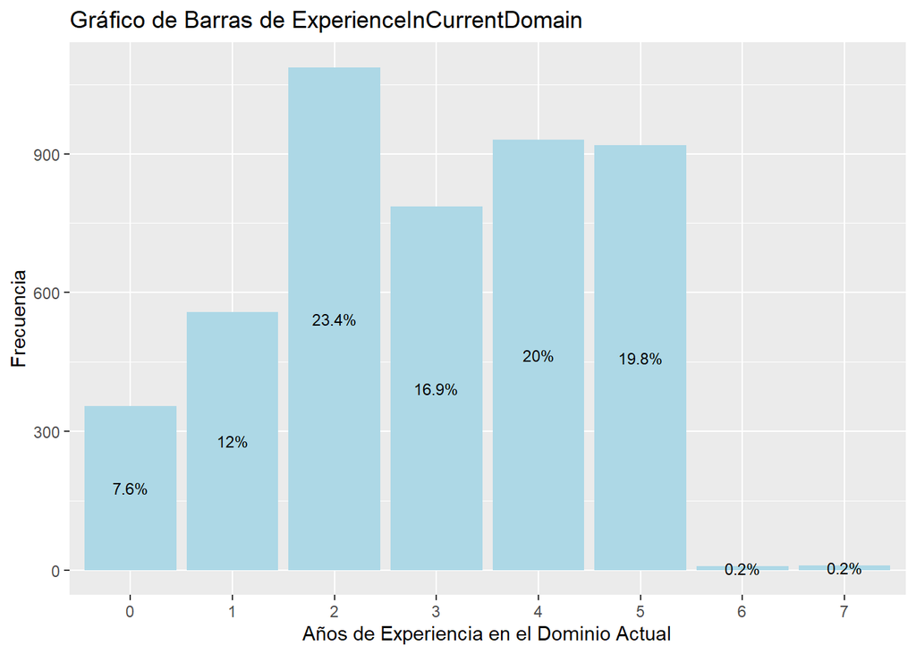

Gráfico de Barras de ExperienceInCurrentDomain con ggplot2

```r
# Calcular los porcentajes de frecuencia de cada valor de ExperienceInCurrentDomain
library(ggplot2)
experience_data <- as.data.frame(table(datos$ExperienceInCurrentDomain))
experience_data$Percentage <- experience_data$Freq / sum(experience_data$Freq) * 100

# Crear el gráfico de barras con porcentajes usando ggplot2
ggplot(experience_data, aes(x = Var1, y = Freq, label = paste0(round(Percentage, 1), "%"))) +
  geom_bar(stat = "identity", fill = "lightblue") +
  geom_text(size = 3, position = position_stack(vjust = 0.5), color = "black") +
  ggtitle("Gráfico de Barras de ExperienceInCurrentDomain") +
  xlab("Años de Experiencia en el Dominio Actual") +
  ylab("Frecuencia")
```

Ahora, analizando nuestra variable dependiente, decidimos realizar un gráfico de barras de LeaveOrNot, debido a que su rango de valores era corto. Podemos observar que la frecuencia más alta es que las personas se queden (65.6%); sin embargo, las personas que se van también representan una parte considerable (34.4%).

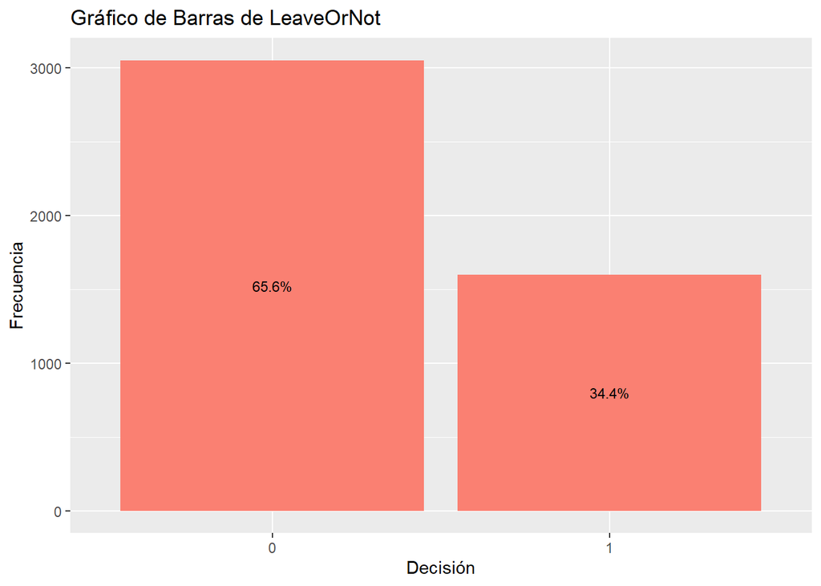

Gráfico de Barras de LeaveOrNot con ggplot2

```r
# Calcular los porcentajes de frecuencia de cada categoría de LeaveOrNot
library(ggplot2)
leave_data <- as.data.frame(table(datos$LeaveOrNot))
leave_data$Percentage <- leave_data$Freq / sum(leave_data$Freq) * 100

# Crear el gráfico de barras con porcentajes usando ggplot2
ggplot(leave_data, aes(x = Var1, y = Freq, label = paste0(round(Percentage, 1), "%"))) +
  geom_bar(stat = "identity", fill = "salmon") +
  geom_text(size = 3, position = position_stack(vjust = 0.5), color = "black") +
  ggtitle("Gráfico de Barras de LeaveOrNot") +
  xlab("Decisión") +
  ylab("Frecuencia")
```

```r
# Identifying character variables
char_vars <- sapply(datos, class) == "character"

# Extracting unique values for each character variable
unique_values <- lapply(datos[, char_vars, drop = FALSE], unique)

# Displaying the unique values
unique_values
```

```
## $Education
## [1] "Bachelors" "Masters"   "PHD"
##
## $City
## [1] "Bangalore" "Pune"      "New Delhi"
##
## $Gender
## [1] "Male"   "Female"
##
## $EverBenched
## [1] "No"  "Yes"
```

Decidimos realizar un gráfico de barras de Education, debido a que era categórico con pocos valores únicos. Podemos observar que la mayor cantidad de personas tienen un título de Bachelor(77.4%), mientras que una pequeña cantidad de personas tienen un título de PhD (3.8%).

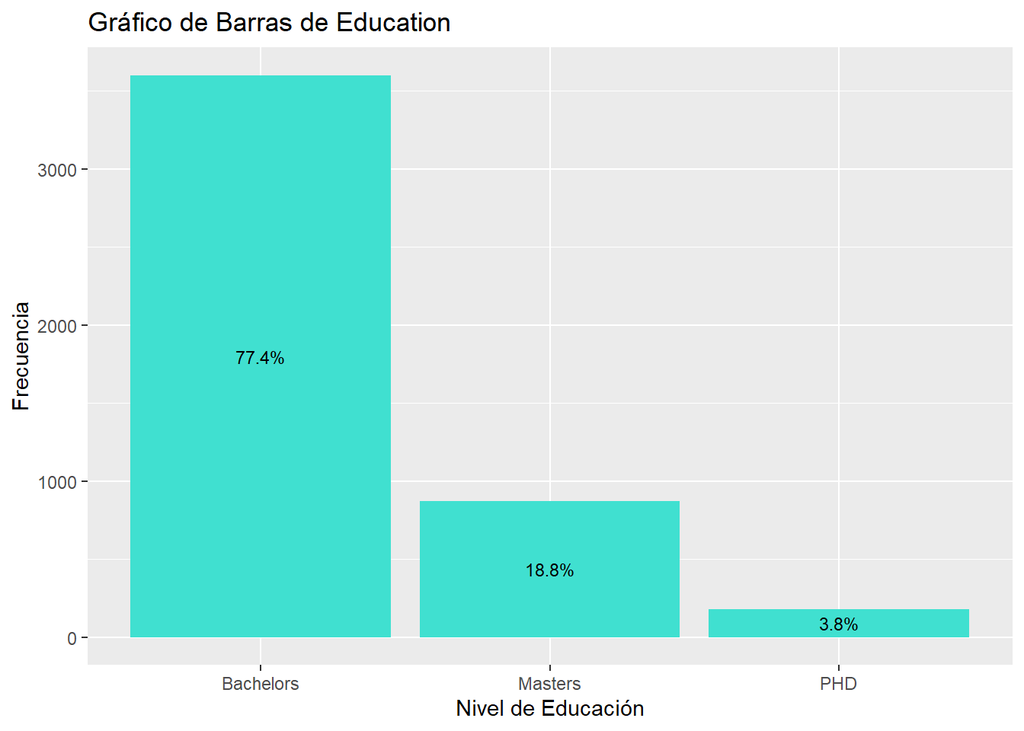

Gráfico de Barras de Education con ggplot2

```r
# Calcular los porcentajes de frecuencia de cada categoría de Education
library(ggplot2)
education_data <- as.data.frame(table(datos$Education))
education_data$Percentage <- education_data$Freq / sum(education_data$Freq) * 100

# Crear el gráfico de barras con porcentajes usando ggplot2
ggplot(education_data, aes(x = Var1, y = Freq, label = paste0(round(Percentage, 1), "%"))) +
  geom_bar(stat = "identity", fill = "turquoise") +
  geom_text(size = 3, position = position_stack(vjust = 0.5), color = "black") +
  ggtitle("Gráfico de Barras de Education") +
  xlab("Nivel de Educación") +
  ylab("Frecuencia")
```

Decidimos realizar un gráfico de barras de City, debido a que era categórico con pocos valores únicos. Podemos observar que la mayor cantidad de personas son de Bangalore (47.9%), mientras que las personas que vienen de Pune y New Delhi tienen proporciones muy similares (27.3% y 24.9% respectivamente).

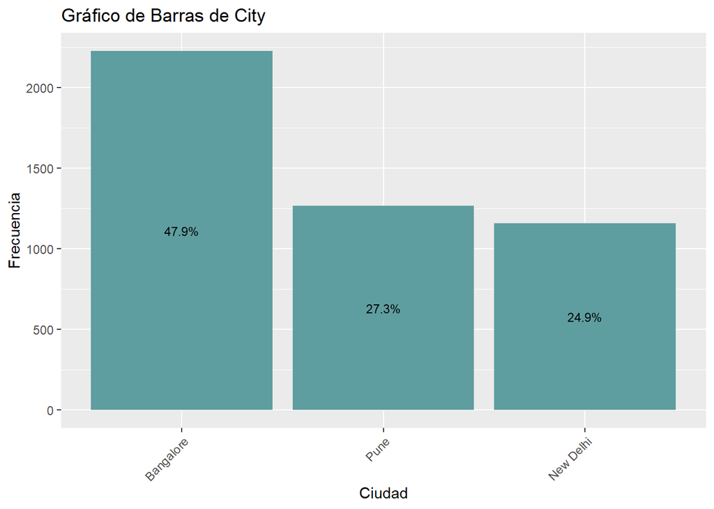

Gráfico de Barras de City con ggplot2

```r
# Calcular los porcentajes de frecuencia de cada ciudad
library(ggplot2)
city_data <- as.data.frame(table(datos$City))
city_data$Percentage <- city_data$Freq / sum(city_data$Freq) * 100

# Crear el gráfico de barras con porcentajes usando ggplot2
ggplot(city_data, aes(x = reorder(Var1, -Freq), y = Freq, label = paste0(round(Percentage, 1), "%"))) +
  geom_bar(stat = "identity", fill = "cadetblue") +
  geom_text(size = 3, position = position_stack(vjust = 0.5), color = "black") +
  ggtitle("Gráfico de Barras de City") +
  xlab("Ciudad") +
  ylab("Frecuencia") +
  theme(axis.text.x = element_text(angle = 45, hjust = 1)) # Rotating x-axis labels for better visibility
```

Decidimos realizar un gráfico de barras de Gender, debido a que era categórico con pocos valores únicos. Podemos observar que la mayor cantidad de personas son del género masculino (59.7%), mientras que la menor proporción son del género femenino (40.3%).

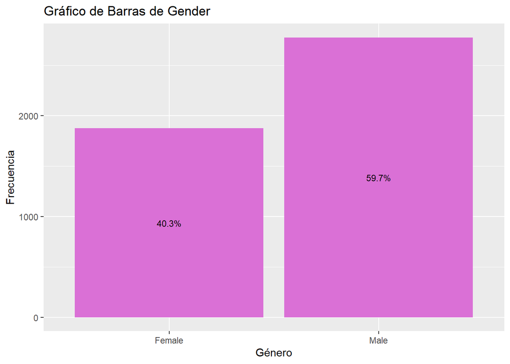

Gráfico de Barras de Gender con ggplot2

```r
# Calcular los porcentajes de frecuencia de cada género
library(ggplot2)
gender_data <- as.data.frame(table(datos$Gender))
gender_data$Percentage <- gender_data$Freq / sum(gender_data$Freq) * 100

# Crear el gráfico de barras con porcentajes usando ggplot2
ggplot(gender_data, aes(x = Var1, y = Freq, label = paste0(round(Percentage, 1), "%"))) +
  geom_bar(stat = "identity", fill = "orchid") +
  geom_text(size = 3, position = position_stack(vjust = 0.5), color = "black") +
  ggtitle("Gráfico de Barras de Gender") +
  xlab("Género") +
  ylab("Frecuencia")
```

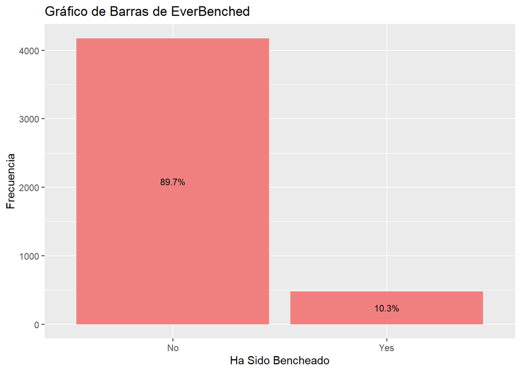

Gráfico de Barras de EverBenched con ggplot2

```r
# Calcular los porcentajes de frecuencia de cada categoría de EverBenched
library(ggplot2)
everbenched_data <- as.data.frame(table(datos$EverBenched))
everbenched_data$Percentage <- everbenched_data$Freq / sum(everbenched_data$Freq) * 100

# Crear el gráfico de barras con porcentajes usando ggplot2
ggplot(everbenched_data, aes(x = Var1, y = Freq, label = paste0(round(Percentage, 1), "%"))) +
  geom_bar(stat = "identity", fill = "lightcoral") +
  geom_text(size = 3, position = position_stack(vjust = 0.5), color = "black") +
  ggtitle("Gráfico de Barras de EverBenched") +
  xlab("Ha Sido Bencheado") +
  ylab("Frecuencia")
```

```r
# Converting 'LeaveOrNot' to a factor if it's not already
datos$LeaveOrNot <- as.factor(datos$LeaveOrNot)
# Optionally, convert other categorical variables
datos$PaymentTier <- as.factor(datos$PaymentTier)

# Now, subset the dataset with the required variables
selected_variables <- datos[, c("Age", "JoiningYear", "ExperienceInCurrentDomain", "PaymentTier", "LeaveOrNot")]
```

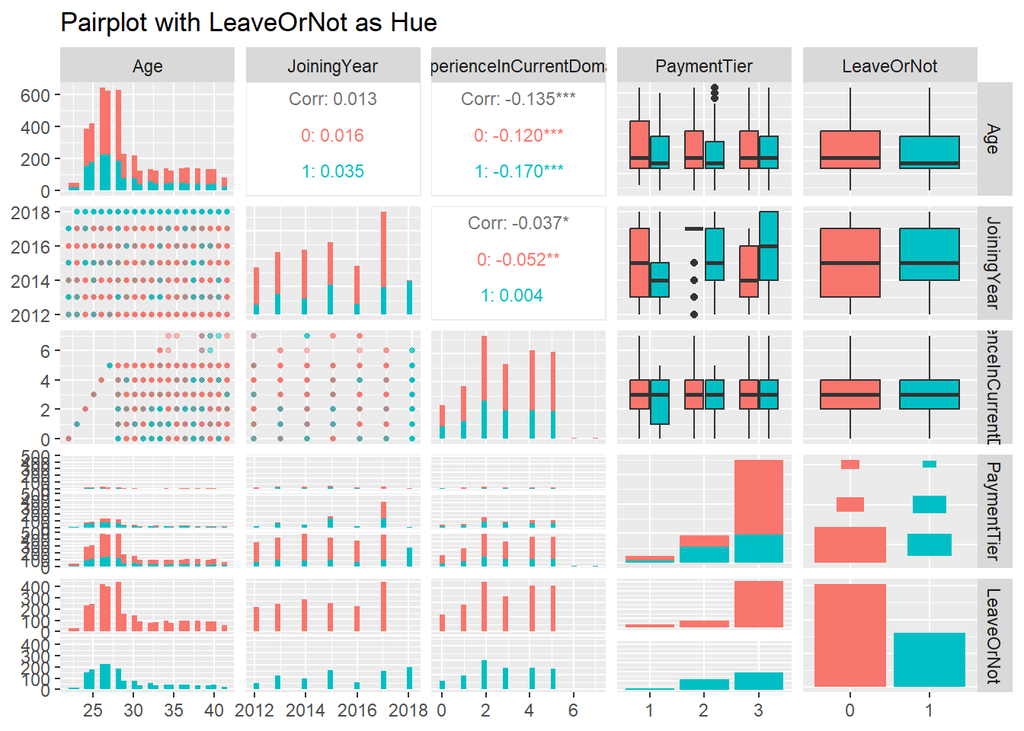

Pairplot with LeaveOrNot as Hue

```r
# Creating the pairplot using GGally
library(GGally)
ggpairs(selected_variables, aes(color = LeaveOrNot),
        lower = list(continuous = wrap("points", alpha = 0.5, size = 1)),
        diag = list(continuous = wrap("barDiag")),
        upper = list(continuous = wrap("cor", size = 3)),
        title = "Pairplot with LeaveOrNot as Hue")
```

```r
# Subsetting the dataset to include only numerical variables
numerical_data <- datos[sapply(datos, is.numeric)]

# Calculating the correlation matrix
cor_matrix <- cor(numerical_data, use="pairwise.complete.obs")  # Handling missing values by considering complete cases

# Display the correlation matrix
cor_matrix
```

```
##                           JoiningYear         Age ExperienceInCurrentDomain
## JoiningYear                1.00000000  0.01316529               -0.03652462
## Age                        0.01316529  1.00000000               -0.13464285
## ExperienceInCurrentDomain -0.03652462 -0.13464285                1.00000000
```

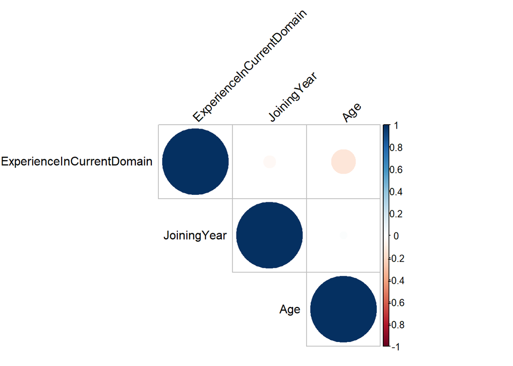

Correlation Matrix Visualization

```r
# Visualizing the correlation matrix
corrplot(cor_matrix, method="circle", type="upper", order="hclust",
         tl.col="black", tl.srt=45)  # Rotate labels for better readability
```

## 3. Estadísticos Inferenciales

```r
#install.packages("ggplot2")
#install.packages("conflicted")
```

```r
# Cargamos las librerias necesarias
library(conflicted)
library(tidyverse)
```

```r
library(ggplot2)
library(reshape2)
```

```r
# CARGAMOS LOS DATOS
df <- datos
```

**CALCULAMOS LA MATRIZ DE CORRELACION**

```r
cor_matrix <- cor(df[, sapply(df, is.numeric)])
cor_matrix
```

```
##                           JoiningYear         Age ExperienceInCurrentDomain
## JoiningYear                1.00000000  0.01316529               -0.03652462
## Age                        0.01316529  1.00000000               -0.13464285
## ExperienceInCurrentDomain -0.03652462 -0.13464285                1.00000000
```

**VISUALIZAMOS LA MATRIZ DE CORRELACION**

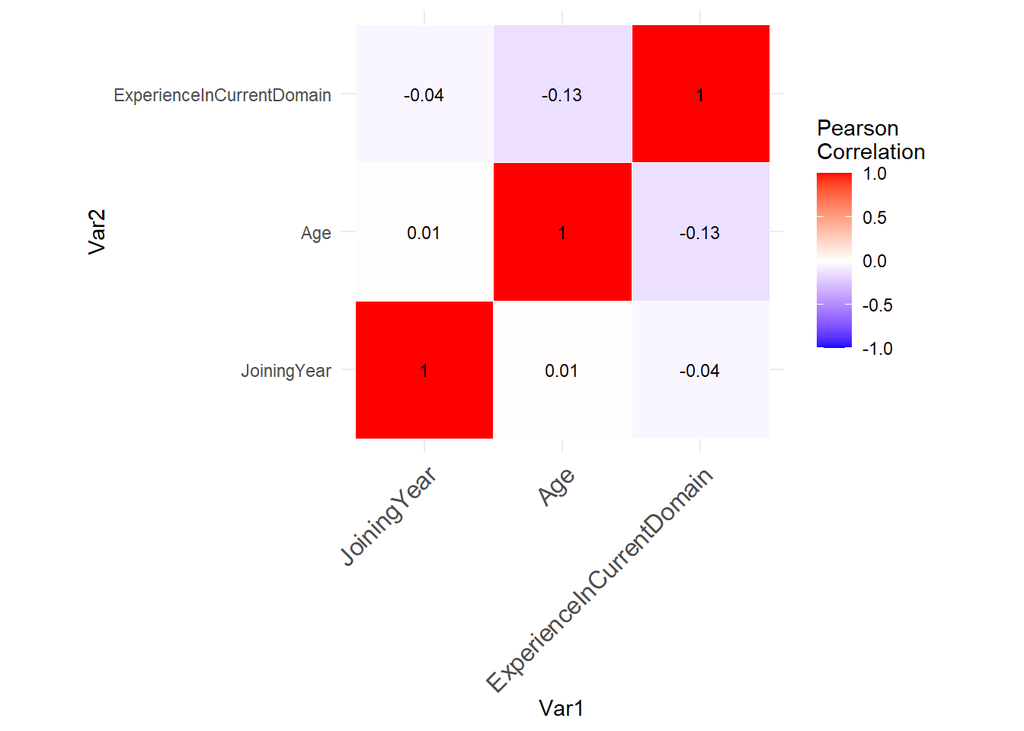

```r
hot_matrix <- melt(cor_matrix)
ggplot(hot_matrix, aes(Var1, Var2, fill=value)) +
  geom_tile(color="white") +
  scale_fill_gradient2(low = "blue", high = "red", mid = "white",
                       midpoint=0, limit=c(-1,1), space="Lab",
                       name="Pearson\nCorrelation") +
  geom_text(aes(Var1, Var2, label = round(value, 2)), color = "black", size = 3) +
  theme_minimal()+
  theme(axis.text.x = element_text(angle = 45, vjust = 1,
                                   size = 12, hjust = 1)) +
  coord_fixed()
```

**La matriz de correlación muestra las siguientes relaciones entre las variables numéricas:**

**REALIZAMOS UN BOX PLOT PARA VER LAS RELACIONES ENTRE LA VARIABLE EDAD Y LA VARIABLE TARGET**

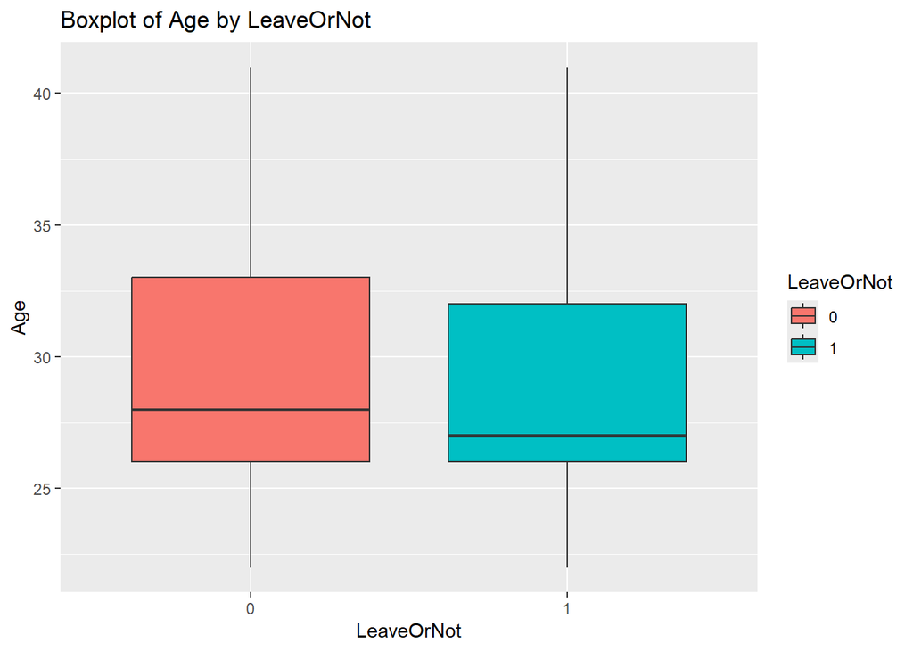

```r
ggplot(df, aes(x=LeaveOrNot, y=Age, fill=LeaveOrNot)) +
  geom_boxplot() +
  labs(title = "Boxplot of Age by LeaveOrNot", x = "LeaveOrNot", y = "Age")
```

**REALIZAMOS UN BOX PLOT PARA VER LAS RELACIONES ENTRE LA VARIABLE ExperienceInCurrentDomain Y LA VARIABLE TARGET**

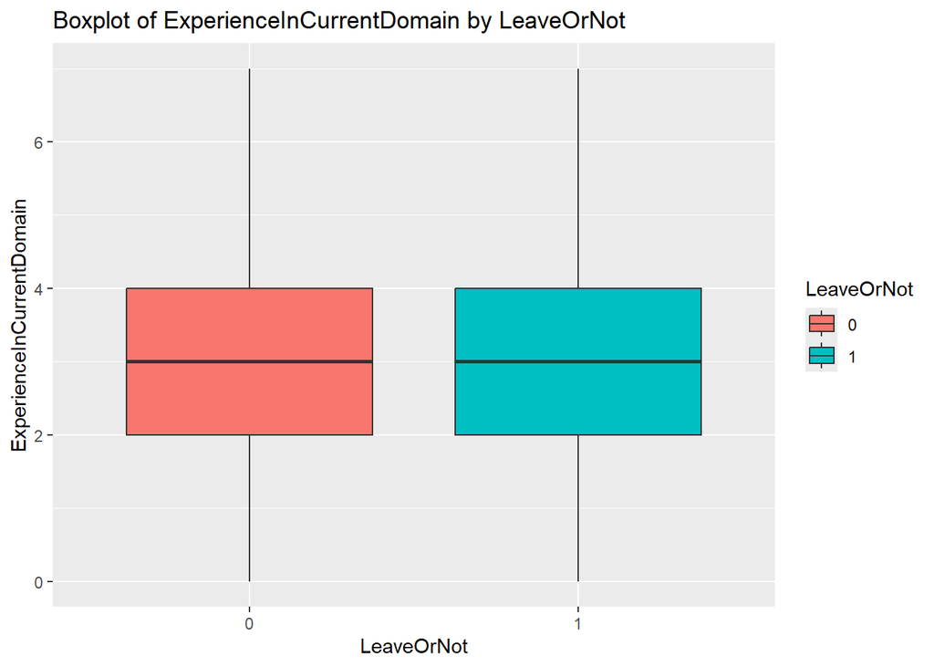

```r
ggplot(df, aes(x=LeaveOrNot, y=ExperienceInCurrentDomain, fill=LeaveOrNot)) +
  geom_boxplot() +
  labs(title = "Boxplot of ExperienceInCurrentDomain by LeaveOrNot", x = "LeaveOrNot", y = "ExperienceInCurrentDomain")
```

- Edad vs. Dejar la Empresa: No parece haber una diferencia significativa en la edad de los empleados que deciden dejar la empresa y los que se quedan.
- Experiencia en el Dominio Actual vs. Dejar la Empresa: Similarmente, la experiencia en el dominio actual no muestra una diferencia clara en términos de afectar la decisión de dejar o no la empresa.

**GRAFICO DE RELACION ENTRE VARIABLES “City” VS “LeaveOrNot”**

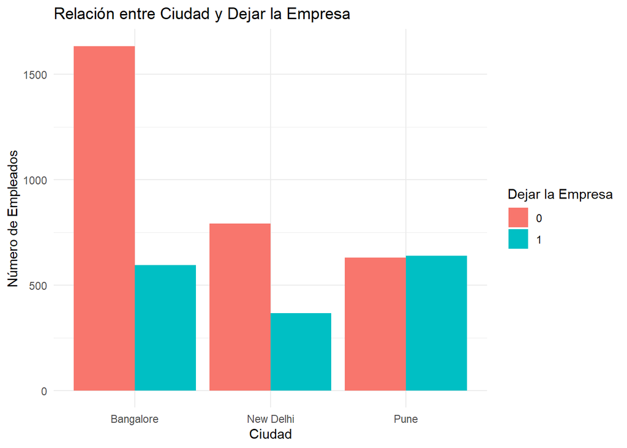

```r
ggplot(data = df, aes(x = City, fill = factor(LeaveOrNot))) +  # Define las variables para el eje X y el color
  geom_bar(position = "dodge", stat = "count") +  # Crea barras separadas para cada grupo en LeaveOrNot
  labs(title = "Relación entre Ciudad y Dejar la Empresa",
       x = "Ciudad",
       y = "Número de Empleados",
       fill = "Dejar la Empresa") +  # Personaliza las etiquetas y título
  theme_minimal()
```

- Del grafico, se puede observar que la mayoria de los empleados que deciden dejar la empresa son de la ciudad de Bangalore y New Delhi.
- Por otro lado, la ciudad de Pune tiene una cantidad similar de empleados que deciden dejar la empresa y los que se quedan.

**GRAFICO DE RELACION ENTRE VARIABLES “Gender” VS “LeaveOrNot”**

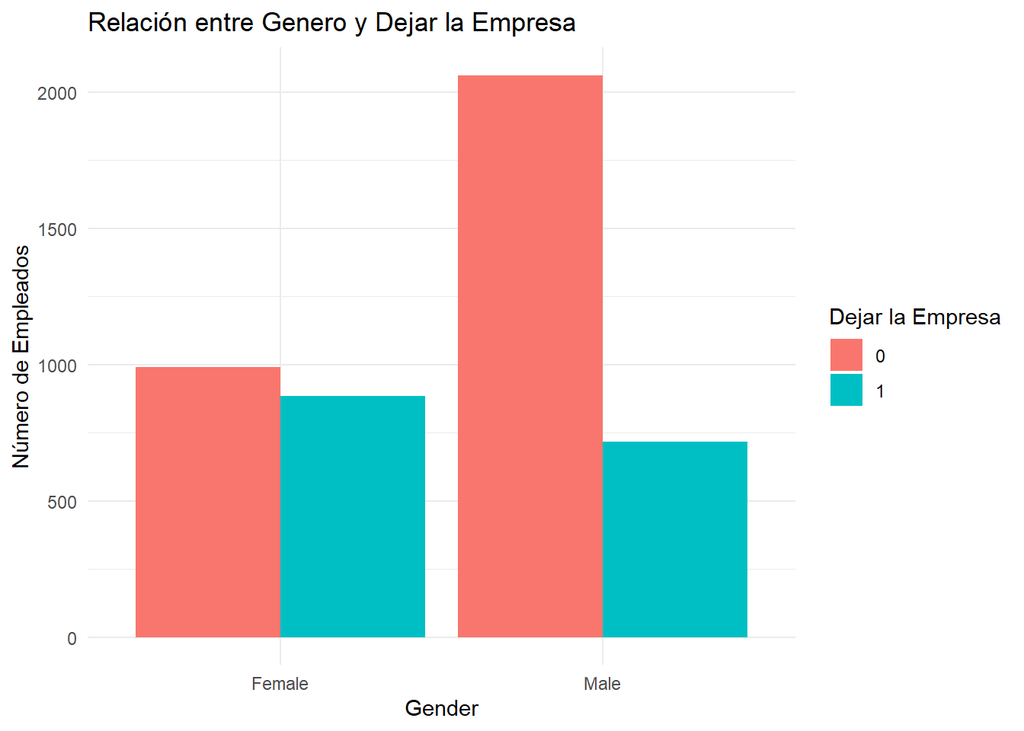

```r
ggplot(data = df, aes(x = Gender, fill = factor(LeaveOrNot))) +  # Define las variables para el eje X y el color
  geom_bar(position = "dodge", stat = "count") +  # Crea barras separadas para cada grupo en LeaveOrNot
  labs(title = "Relación entre Genero y Dejar la Empresa",
       x = "Gender",
       y = "Número de Empleados",
       fill = "Dejar la Empresa") +  # Personaliza las etiquetas y título
  theme_minimal()
```

**GRAFICO DE RELACION ENTRE VARIABLES “Education” VS “LeaveOrNot”**

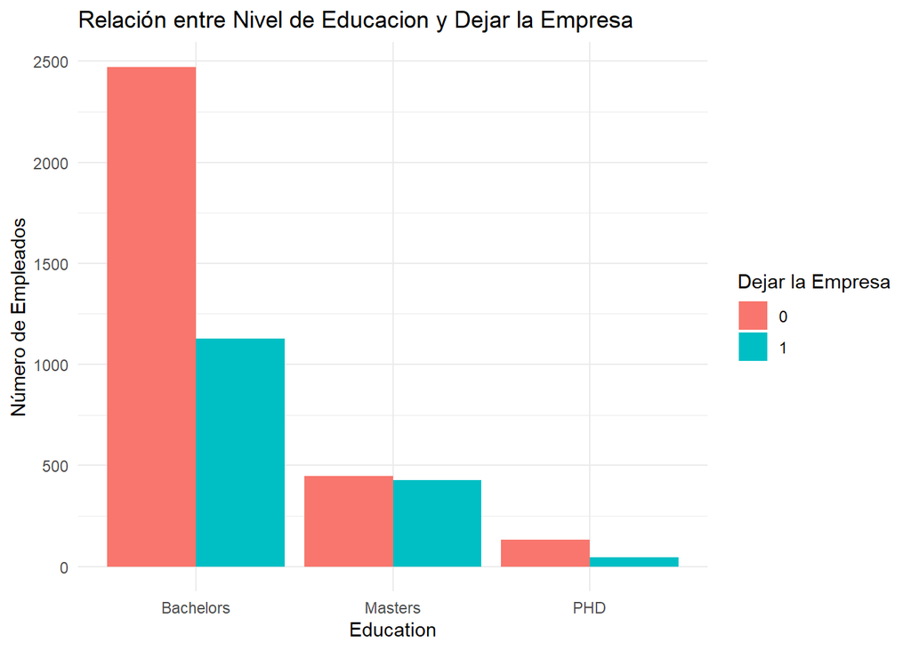

```r
ggplot(data = df, aes(x = Education, fill = factor(LeaveOrNot))) +  # Define las variables para el eje X y el color
  geom_bar(position = "dodge", stat = "count") +  # Crea barras separadas para cada grupo en LeaveOrNot
  labs(title = "Relación entre Nivel de Educacion y Dejar la Empresa",
       x = "Education",
       y = "Número de Empleados",
       fill = "Dejar la Empresa") +  # Personaliza las etiquetas y título
  theme_minimal()
```

**PRUEBA DE HIPOTESIS**

-Para determinar si estas diferencias son estadísticamente significativas, procederemos a realizar pruebas de Chi-cuadrado. Estas pruebas nos permitirán evaluar si las diferencias observadas en cada grupo son suficientes para sugerir una dependencia entre las variables categóricas y la decisión de dejar la empresa.

```r
# PRUEBA DE CHI-CUADRADO PARA CIUDAD
city_table <- table(df$City, df$LeaveOrNot)
city_table
```

```
##
##                0    1
##   Bangalore 1633  595
##   New Delhi  791  366
##   Pune       629  639
```

```r
CH2_CITY <- chisq.test(city_table)
CH2_CITY
```

```
##
##  Pearson's Chi-squared test
##
## data:  city_table
## X-squared = 206.16, df = 2, p-value < 2.2e-16
```

```r
# PRUEBA DE CHI-CUADRADO PARA GENERO
gender_table <- table(df$Gender, df$LeaveOrNot)
gender_table
```

```
##
##             0    1
##   Female  991  884
##   Male   2062  716
```

```r
CH2_GENDER <- chisq.test(gender_table)
CH2_GENDER
```

```
##
##  Pearson's Chi-squared test with Yates' continuity correction
##
## data:  gender_table
## X-squared = 225.7, df = 1, p-value < 2.2e-16
```

```r
# PRUEBA DE CHI-CUADRADO PARA EDUCACION
education_table <- table(df$Education, df$LeaveOrNot)
education_table
```

```
##
##                0    1
##   Bachelors 2472 1129
##   Masters    447  426
##   PHD        134   45
```

```r
CH2_EDUCATION <- chisq.test(education_table)
CH2_EDUCATION
```

```
##
##  Pearson's Chi-squared test
##
## data:  education_table
## X-squared = 101.83, df = 2, p-value < 2.2e-16
```

- La prueba de Chi-cuadrado para la variable “City” muestra un valor de p-value < 2.2e-16, lo que indica que hay una relación significativa entre la ciudad de los empleados y su decisión de dejar la empresa.
- La prueba de Chi-cuadrado para la variable “Gender” muestra un valor de p-value < 2.2e-16, lo que indica que hay una relación significativa entre el género de los empleados y su decisión de dejar la empresa.
- La prueba de Chi-cuadrado para la variable “Education” muestra un valor de p-value < 2.2e-16, lo que indica que hay una relación significativa entre el nivel de educación de los empleados y su decisión de dejar la empresa.